# Topic Models

Tom Paskhalis

31 January, 2019

```r
library("readr")
library("dplyr")
library("quanteda")
library("topicmodels")
library("stm")
```

## US Senate

To fit topic models, we will restrict our analysis to US Senate. First, it makes our corpus smaller and, thus, speed up estimation process. And, second, it contains some covariates that we might be interested in when fitting structural topic models. Let us first read in the datasets and combine them together as in the previous part.

```r
# Senate
us_senate_2017 <- readr::read_csv("../data/us-senate-2017.csv.gz")
us_senate_2018 <- readr::read_csv("../data/us-senate-2018.csv.gz")

senate115 <- us_senate_2017 %>%
  dplyr::bind_rows(us_senate_2018)

nrow(senate115)
```

```
## [1] 38878
```

```r
head(senate115, 10)
```

```
## # A tibble: 10 x 16
##    chamber speaker date       text  first_name last_name party gender
##    <chr>   <chr>   <date>     <chr> <chr>      <chr>     <chr> <chr>
##  1 S       The VI… 2017-01-03 The … <NA>       <NA>      <NA>  <NA>
##  2 S       Mr COR… 2017-01-03 Mr. … John       cornyn    Repu… M
##  3 S       The PR… 2017-01-03 The … <NA>       <NA>      <NA>  <NA>
##  4 S       Mr DUR… 2017-01-03 Mr. … Richard    durbin    Demo… M
##  5 S       Mr MER… 2017-01-03 Mr. … Jeff       merkley   Demo… M
##  6 S       The PR… 2017-01-03 The … <NA>       <NA>      <NA>  <NA>
##  7 S       Mr McC… 2017-01-03 Mr. … Mitch      mcconnell Repu… M
##  8 S       The PR… 2017-01-03 With… <NA>       <NA>      <NA>  <NA>
##  9 S       Mr DUR… 2017-01-03 Mr. … Richard    durbin    Demo… M
## 10 S       The PR… 2017-01-03 The … <NA>       <NA>      <NA>  <NA>
## # … with 8 more variables: birthday <date>, state <chr>, url <chr>,
## #   twitter <chr>, facebook <chr>, govtrack_id <dbl>, icpsr_id <dbl>,
## #   votesmart_id <dbl>
```

After inspecting the dataset, we can see that a lot of the rows contain procedural statements by presiding officers of the Senate. As we might be interested in the topical content of the speeches, rather than procedural discussion, we can remove those:

```r
senate115 <- senate115 %>%
  dplyr::filter(!is.na(first_name))

nrow(senate115)
```

```
## [1] 20683
```

```r
head(senate115, 10)
```

```
## # A tibble: 10 x 16
##    chamber speaker date       text  first_name last_name party gender
##    <chr>   <chr>   <date>     <chr> <chr>      <chr>     <chr> <chr>
##  1 S       Mr COR… 2017-01-03 Mr. … John       cornyn    Repu… M
##  2 S       Mr DUR… 2017-01-03 Mr. … Richard    durbin    Demo… M
##  3 S       Mr MER… 2017-01-03 Mr. … Jeff       merkley   Demo… M
##  4 S       Mr McC… 2017-01-03 Mr. … Mitch      mcconnell Repu… M
##  5 S       Mr DUR… 2017-01-03 Mr. … Richard    durbin    Demo… M
##  6 S       Mr COR… 2017-01-03 Mr. … Bob        corker    Repu… M
##  7 S       Mr PET… 2017-01-03 Mr. … Gary       peters    Demo… M
##  8 S       Mr MOR… 2017-01-03 Mr. … Jerry      moran     Repu… M
##  9 S       Mr McC… 2017-01-03 Mr. … Mitch      mcconnell Repu… M
## 10 S       Mr McC… 2017-01-03 Mr. … Mitch      mcconnell Repu… M
## # … with 8 more variables: birthday <date>, state <chr>, url <chr>,
## #   twitter <chr>, facebook <chr>, govtrack_id <dbl>, icpsr_id <dbl>,
## #   votesmart_id <dbl>
```

Although we lost some observations, it is still a quite sizeable dataset. Now, we can proceed with creating a corpus and dfm in the usual way.

```r
corpus115 <- quanteda::corpus(senate115)
head(quanteda::docvars(corpus115), 10)
```

```
##        chamber      speaker       date first_name last_name      party
## text1        S    Mr CORNYN 2017-01-03       John    cornyn Republican
## text2        S    Mr DURBIN 2017-01-03    Richard    durbin   Democrat
## text3        S   Mr MERKLEY 2017-01-03       Jeff   merkley   Democrat
## text4        S Mr McCONNELL 2017-01-03      Mitch mcconnell Republican
## text5        S    Mr DURBIN 2017-01-03    Richard    durbin   Democrat
## text6        S    Mr CORKER 2017-01-03        Bob    corker Republican
## text7        S    Mr PETERS 2017-01-03       Gary    peters   Democrat
## text8        S     Mr MORAN 2017-01-03      Jerry     moran Republican
## text9        S Mr McCONNELL 2017-01-03      Mitch mcconnell Republican
## text10       S Mr McCONNELL 2017-01-03      Mitch mcconnell Republican
##        gender   birthday state                              url
## text1       M 1952-02-02    TX    https://www.cornyn.senate.gov
## text2       M 1944-11-21    IL    https://www.durbin.senate.gov
## text3       M 1956-10-24    OR   https://www.merkley.senate.gov
## text4       M 1942-02-20    KY https://www.mcconnell.senate.gov
## text5       M 1944-11-21    IL    https://www.durbin.senate.gov
## text6       M 1952-08-24    TN    https://www.corker.senate.gov
## text7       M 1958-12-01    MI    https://www.peters.senate.gov
## text8       M 1954-05-29    KS     https://www.moran.senate.gov
## text9       M 1942-02-20    KY https://www.mcconnell.senate.gov
## text10      M 1942-02-20    KY https://www.mcconnell.senate.gov
##               twitter       facebook govtrack_id icpsr_id votesmart_id
## text1      JohnCornyn sen.johncornyn      300027    40305        15375
## text2   SenatorDurbin  SenatorDurbin      300038    15021        26847
## text3  SenJeffMerkley    jeffmerkley      412325    40908        23644
## text4  McConnellPress mitchmcconnell      300072    14921        53298
## text5   SenatorDurbin  SenatorDurbin      300038    15021        26847
## text6    SenBobCorker      bobcorker      412248    40705        65905
## text7   SenGaryPeters  SenGaryPeters      412305    20923         8749
## text8      JerryMoran     jerrymoran      400284    29722          542
## text9  McConnellPress mitchmcconnell      300072    14921        53298
## text10 McConnellPress mitchmcconnell      300072    14921        53298
```

```r
summary(corpus115, 10)
```

```
## Corpus consisting of 20683 documents, showing 10 documents:
##
##    Text Types Tokens Sentences chamber      speaker       date first_name
##   text1   592   1917        69       S    Mr CORNYN 2017-01-03       John
##   text2   781   2542       137       S    Mr DURBIN 2017-01-03    Richard
##   text3   635   2334        91       S   Mr MERKLEY 2017-01-03       Jeff
##   text4    16     18         1       S Mr McCONNELL 2017-01-03      Mitch
##   text5    64    102         7       S    Mr DURBIN 2017-01-03    Richard
##   text6  1450   6749       258       S    Mr CORKER 2017-01-03        Bob
##   text7   303    667        30       S    Mr PETERS 2017-01-03       Gary
##   text8   288    640        26       S     Mr MORAN 2017-01-03      Jerry
##   text9    41     57         2       S Mr McCONNELL 2017-01-03      Mitch
##  text10    51     70         1       S Mr McCONNELL 2017-01-03      Mitch
##  last_name      party gender   birthday state
##     cornyn Republican      M 1952-02-02    TX
##     durbin   Democrat      M 1944-11-21    IL
##    merkley   Democrat      M 1956-10-24    OR
##  mcconnell Republican      M 1942-02-20    KY
##     durbin   Democrat      M 1944-11-21    IL
##     corker Republican      M 1952-08-24    TN
##     peters   Democrat      M 1958-12-01    MI
##      moran Republican      M 1954-05-29    KS
##  mcconnell Republican      M 1942-02-20    KY
##  mcconnell Republican      M 1942-02-20    KY
##                               url        twitter       facebook
##     https://www.cornyn.senate.gov     JohnCornyn sen.johncornyn
##     https://www.durbin.senate.gov  SenatorDurbin  SenatorDurbin
##    https://www.merkley.senate.gov SenJeffMerkley    jeffmerkley
##  https://www.mcconnell.senate.gov McConnellPress mitchmcconnell
##     https://www.durbin.senate.gov  SenatorDurbin  SenatorDurbin
##     https://www.corker.senate.gov   SenBobCorker      bobcorker
##     https://www.peters.senate.gov  SenGaryPeters  SenGaryPeters
##      https://www.moran.senate.gov     JerryMoran     jerrymoran
##  https://www.mcconnell.senate.gov McConnellPress mitchmcconnell
##  https://www.mcconnell.senate.gov McConnellPress mitchmcconnell
##  govtrack_id icpsr_id votesmart_id
##       300027    40305        15375
##       300038    15021        26847
##       412325    40908        23644
##       300072    14921        53298
##       300038    15021        26847
##       412248    40705        65905
##       412305    20923         8749
##       400284    29722          542
##       300072    14921        53298
##       300072    14921        53298
##
## Source: /home/tpaskhalis/Decrypted/Git/VAM_Text_Analysis/code/* on x86_64 by tpaskhalis
## Created: Fri Mar 29 09:53:40 2019
## Notes:
```

As some speeches might be very short and not very informative, let us first trim the corpus by applying `corpus_trim()` function.

```r
pre <- quanteda::ndoc(corpus115)

corpus115 <- corpus115 %>%
  quanteda::corpus_trim(what = "documents", min_ntoken = 10)

post <- quanteda::ndoc(corpus115)
c(pre, post, pre-post)
```

```
## [1] 20683 18955  1728
```

To make the model less computationally expensive, we will reduce the number of features by stemming the tokens.

```r
dfm115 <- quanteda::dfm(corpus115,
                        tolower = TRUE,
                        stem = TRUE,
                        remove = stopwords("english"),
                        remove_punct = TRUE)
```

Before fitting the model, let us further trim the dataset by removing infrequent tokens. To do that, we will be using `dfm_trim()` function. There are several options to trim the dfm. One, which we are using here is to specify the minimum number of documents in which a given token occurs (`min_docfreq`). Another would be to specify the minimum number of times a token should be used across all the documents (`min_termfreq`) to remain in the dfm.

```r
dfm115 <- quanteda::dfm_trim(dfm115, min_docfreq = 2)
```

## Latent Dirichlet Allocation (LDA)

Let us start with the original implementation of topic models, also called Latent Dirichlet Allocation (or LDA for short). Another way to think about a topic model is as Bayesian mixed-membership. If you have encountered mixture models before, where each observed unit (say, an individual) belongs to a latent class, here we allow each observed unit (document) to belong to multiple classes.

We will be using the package `topicmodels` and function `LDA()`. This is essentially an R wrapper around C code, implemented by the authors of LDA.

The crucial analytical decision to be made when fitting a topic model is to specify a number of topics ($k$). Here, we will just pick 10 as a starting value and then come back to diagnostics at a later stage. To run MCMC sampler we specify the `burnin` period of 100 iterations, that are discarded from the analysis of resultant chains and keep the remaining 500 (It is a relatively low number and in real-life analysis, it is better to have a few thousand iterations). The parameter `verbose` is just an integer indicating the number of iterations after which the output gets updated while the model is running.

```r
k <- 10
lda <- topicmodels::LDA(dfm115,
                        k = k,
                        method = "Gibbs",
                        control = list(verbose=25L,
                                       seed = 123,
                                       burnin = 100,
                                       iter = 500))
```

Instead of using more traditional Gibbs sampling for Bayesian estimation, we can also try variational inference (`VEM`). Experiment with this. Mind that corpus is still considerably large. It might take some time for this model to converge!

```r
k <- 10
lda <- topicmodels::LDA(dfm115,
                        k = k,
                        method = "VEM")
```

After fitting the model, we can inspect the top `n` terms from the model with `get_terms()` function and predict top `k` topcs for each document with `get_topics()` function.

```r
topicmodels::terms(lda, 10)
```

```
##       Topic 1   Topic 2 Topic 3    Topic 4    Topic 5    Topic 6
##  [1,] "presid"  "go"    "tax"      "defens"   "senat"    "act"
##  [2,] "judg"    "peopl" "american" "nation"   "mr"       "section"
##  [3,] "court"   "get"   "busi"     "secur"    "presid"   "1"
##  [4,] "senat"   "want"  "bill"     "support"  "committe" "state"
##  [5,] "law"     "say"   "job"      "militari" "ask"      "2"
##  [6,] "nomin"   "know"  "compani"  "u."       "unanim"   "shall"
##  [7,] "nomine"  "one"   "percent"  "unit"     "consent"  "b"
##  [8,] "justic"  "just"  "make"     "system"   "order"    "includ"
##  [9,] "confirm" "think" "year"     "state"    "session"  "may"
## [10,] "vote"    "us"    "work"     "forc"     "vote"     "committe"
##       Topic 7     Topic 8     Topic 9    Topic 10
##  [1,] "school"    "state"     "countri"  "care"
##  [2,] "educ"      "nation"    "law"      "health"
##  [3,] "serv"      "water"     "state"    "insur"
##  [4,] "year"      "chang"     "american" "healthcar"
##  [5,] "work"      "climat"    "right"    "bill"
##  [6,] "student"   "energi"    "protect"  "peopl"
##  [7,] "communiti" "industri"  "presid"   "afford"
##  [8,] "state"     "protect"   "peopl"    "american"
##  [9,] "servic"    "year"      "children" "state"
## [10,] "public"    "administr" "unit"     "act"
```

```r
head(topicmodels::topics(lda, 1), 10)
```

```
##  text1  text2  text3  text4  text5  text6  text7  text8  text9 text10
##      2      2      2      5      2      4      7      4      5      5
```

## Structural Topic Models (STM)

The original approach for topic modelling did not allow for the topical content to depend on any of the document covariates. Structural topic models introduced the possibility to incorporate this metadata into the estimation process. Here we will be using `stm` package and the function with the same name: `stm()`. Let us start with incorporating gender as a covariate.

```r
stm115 <- stm::stm(dfm115, K = k, data = docvars(dfm115), prevalence = ~ gender)
```

To view the top terms by various statistics we can use `laelTopics()` function:

```r
stm::labelTopics(stm115, n = 10)
```

```
## Topic 1 Top Words:
##       Highest Prob: school, year, work, serv, educ, state, student, communiti, servic, famili
##       FREX: selfless, championship, ywca, devo, 1943, patterson, monson, thad, museum, smithsonian
##       Lift: 1,000-mile, 1,177, 1.45, 10,000th, 105th, 114-265, 116th, 125th, 130th, 14-15
##       Score: school, student, devo, love, educ, veteran, teacher, betsi, mani, graduat
## Topic 2 Top Words:
##       Highest Prob: senat, mr, presid, ask, unanim, consent, order, amend, committe, motion
##       FREX: adjourn, 1628, bloc, yea, nay, reconsid, motion, rescind, unanim, consent
##       Lift: 1628, 1007, 1032, 1033, 1038, 1039, 1055, 1057, 1065, 1082
##       Score: consent, unanim, motion, rescind, p.m, 1628, adjourn, h.r, session, reconsid
## Topic 3 Top Words:
##       Highest Prob: section, shall, committe, 1, act, state, author, b, 2, unit
##       FREX: subsect, u.s.c, subparagraph, outlay, p.l, n.a, seq, paragraph, sec, subclaus
##       Lift: 1351, 1396a, 2,280,970, 2,281,616, 2017-2026, 303, 715,835, prereleas, subclaus, p.l
##       Score: subsect, subparagraph, shall, u.s.c, section, b, paragraph, sec, outlay, p.l
## Topic 4 Top Words:
##       Highest Prob: state, water, climat, energi, year, chang, epa, nation, industri, just
##       FREX: epa, pruitt, mercuri, solar, greenhous, dioxid, coal, fossil, climat, oil
##       Lift: 111,000, 18.7, 20-to-1, 2075, 222nd, 36.5, 999, absorpt, agronomi, airboat
##       Score: epa, pruitt, climat, pollut, fossil, carbon, farmer, wildlif, farm, emiss
## Topic 5 Top Words:
##       Highest Prob: judg, court, senat, presid, nomine, nomin, law, vote, justic, suprem
##       FREX: kavanaugh, gorsuch, suprem, judg, nomine, court, scalia, ford, circuit, judici
##       Lift: 101-year, 102,000, 182,000, 228-year, 230-year, 290-plus, 30-plus-year-old, 4-4, 4-to-4, 5-to
##       Score: judg, kavanaugh, gorsuch, court, nomine, suprem, justic, nomin, judici, circuit
## Topic 6 Top Words:
##       Highest Prob: committe, investig, general, member, inform, attorney, intellig, report, elect, director
##       FREX: comey, haspel, rosenstein, cia, fda, russian, interfer, mueller, transcript, investig
##       Lift: 39-minut, 514.110, 6,700-page, 90-9, abd, al-nashiri, alfa-bank, anada, anda, archibald
##       Score: russian, investig, fda, russia, fbi, comey, intellig, attorney, cia, trump
## Topic 7 Top Words:
##       Highest Prob: presid, peopl, countri, state, us, one, unit, american, senat, go
##       FREX: daca, dreamer, iran, sanction, zte, china, syrian, putin, backpag, refuge
##       Lift: 1,200-mile, 10-day, 2,342, 2,370, 32-year-old, 51-49, 62-page, 790,000, 800-percent, 846-percent
##       Score: daca, putin, dreamer, peopl, immigr, trump, just, say, russia, iran
## Topic 8 Top Words:
##       Highest Prob: defens, support, system, militari, internet, propos, servic, sale, u., forc
##       FREX: hardwar, mde, non-md, herewith, warhead, mk, launcher, ajit, isp, low-yield
##       Lift: 1.06, 1.3b, 100.0, 10514, 15-70, 1b, 2,500-6,000, 22m, 24-channel, 250-lb
##       Score: missil, mde, non-md, herewith, transmitt, fcc, internet, aircraft, vii, softwar
## Topic 9 Top Words:
##       Highest Prob: bill, provid, feder, program, support, state, busi, work, act, legisl
##       FREX: cfpb, loan, dodd-frank, bank, lender, consum, onewest, financi, cra, workforc
##       Lift: assigne, osha, piwowar, onewest, 12.50, 13.2, 1504, 2009-2011, 2216, 23.688
##       Score: bank, worker, regul, program, financi, consum, loan, cfpb, veteran, dodd-frank
## Topic 10 Top Words:
##       Highest Prob: peopl, tax, go, bill, get, american, care, health, year, insur
##       FREX: obamacar, trumpcar, medicaid, tax, healthcar, insur, premium, afford, medicar, cut
##       Lift: 0-percent, 1.9-percent, 10.5-percent, 12,900, 12.9, 14,600, 14504, 16-bed, 16-percent, 190,000
##       Score: tax, medicaid, insur, obamacar, healthcar, get, peopl, go, premium, medicar
```

To plot the estimated effect of gender on the topics, we can use `estimateEffect()` function from the `stm` package and an in-built `plot` method for the resultant object.

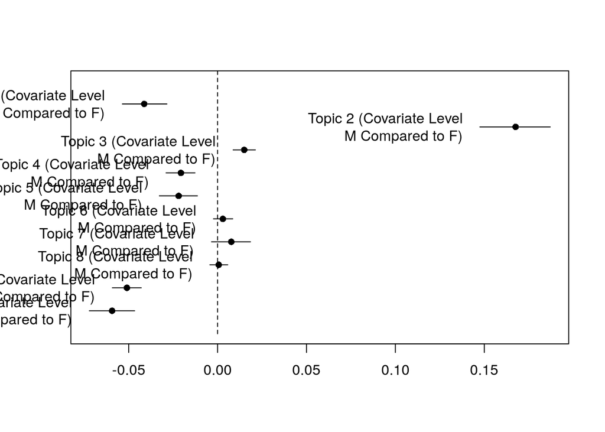

```r
md115 <- stm::estimateEffect(1:10 ~ gender, stmobj = stm115, metadata = docvars(dfm115))
plot(md115, "gender", cov.value1 = "M", cov.value2 = "F", method = "difference")
```

A few other useful functions in the `stm` package are `searchK()` for the diagnostics of the number of topics, `topicQuality()` for assesing the quality of the model fit. See the examples below:

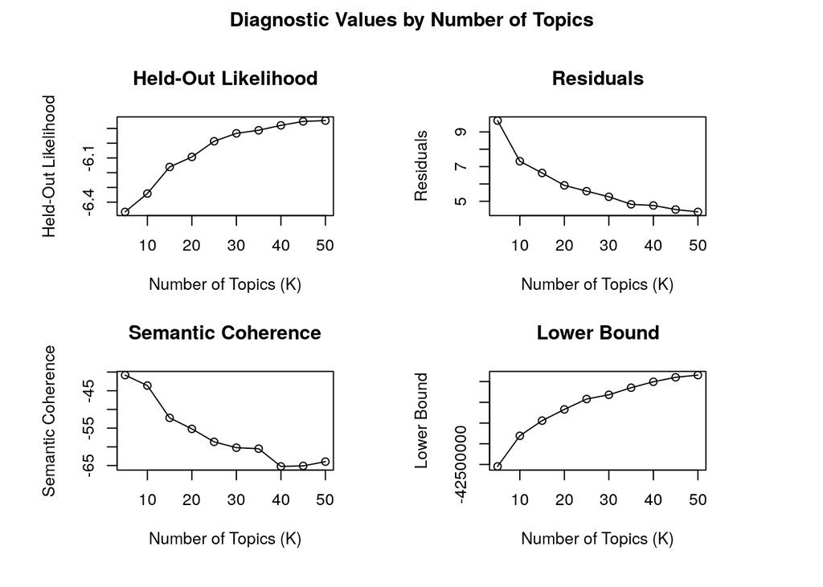

```r
# Before we can proceed with using searchK, we need to prepare our dfm.
dfm115stm <- quanteda::convert(dfm115, to = "stm", docvars = docvars(dfm115))
kdiag <- searchK(documents = dfm115stm[["documents"]],
                 vocab = dfm115stm[["vocab"]],
                 K = seq(5,50,5))
plot(kdiag)
```

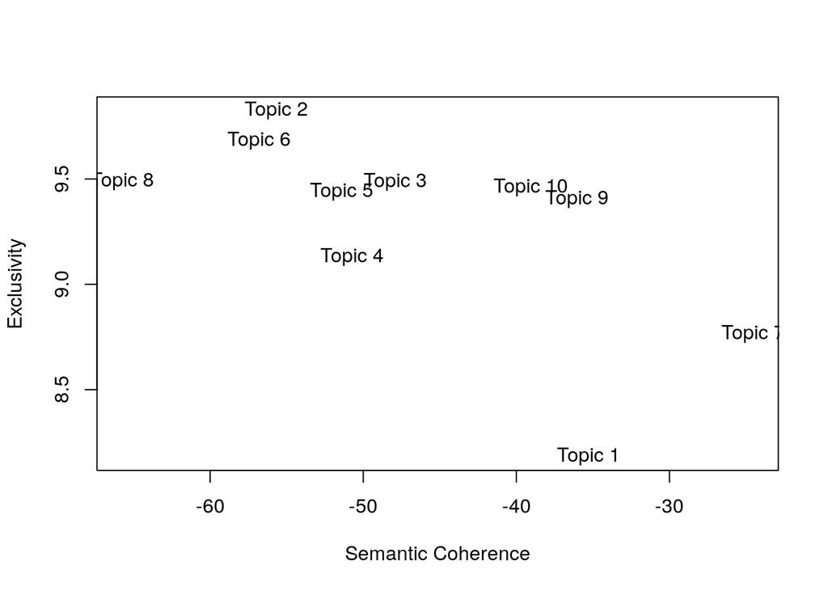

```r
stm::topicQuality(stm115, documents = dfm115)
```

## Challenge 3

**Easy mode** Experiment with `LDA` by fitting it with a different number of topics and observing how it affects the top terms.

**Medium** Calculate age in years for each senator and use it alongside gender as a covariate for topic models. Use `lubridate` package for calculating the age.

**Advanced** Produce a coefficients plot for the estimated model. Try `ggplot2` package to make it appear nicer.